# Taxi Outline

Christoph, Chris, Carol

4/19/2017

### 2015 Yellow Taxi Trip Data - NYC Open Data

https://data.cityofnewyork.us/Transportation/2015-Yellow-Taxi-Trip-Data/ba8s-jw6u

## Libraries

```r
library(dplyr)
```

```r
library(ggplot2)
library(leaps)
library(lubridate)
library(MASS)
library(ggmap)
library(mapproj)
library(gridExtra)
library(grid)
```

## Cleaning

Create `tip_pct`

Create `pickup_hour` and `dropoff_hour`

Only consider longitudes and latitudes in Manhatten

Remove `trip_distance` = 0

Remove `passenger_count` = 0 and create factor variable for passenger count

Create `trip_duration`

Create `avg_speed`

Remove NAs

```r
taxi <- na.omit(taxi)
```

## Generic Map Plot Function

```r
# Gives Heat Plot of Manhattan showing average of desired variable for each region.
  # data: data frame from which data is drawn
  # varialbe: vector of the variable under consideration
  # lat_type: either "pickup" or "dropoff", depending on desired location by which to group data
  # GRID_RESOLUTION: integer representing number of subdivisions of longitude and latitude
  # title: string containing plot title
  # varname: string containing variable name
  # MINLAT, MAXLAT, MINLONG, MAXLONG: specify area covered by plot

locationPlot <- function(data, variable, lat_type = "pickup", GRID_RESOLUTION = 100,
                         title = "Add Title", varname = "Variable", MINLAT = 40.675,
                         MAXLAT = 40.85, MINLONG = -74.1, MAXLONG = -73.85) {

  data$variable <- variable

  if(lat_type == "pickup") {
    # Select all taxi rides whose pickup was within specified region. Stores
    # these rides to a new data frame 'pos'
    pos <- filter(data, pickup_longitude < MAXLONG, pickup_longitude > MINLONG,
                  pickup_latitude < MAXLAT, pickup_latitude > MINLAT)
    # Remove all rows with dropoff longitude or latitude equal to 0
    pos <- filter(pos, dropoff_longitude != 0, dropoff_latitude!= 0)
    # Remove all rows where pickup and dropoff locations are the same
    pos <- filter(pos, dropoff_longitude != pickup_longitude,
                  dropoff_latitude != pickup_latitude)
    # Cut latitude into bins
    pos$lat_region <- cut(pos$pickup_latitude,GRID_RESOLUTION)
    # Cut longitude into bins
    pos$long_region <- cut(pos$pickup_longitude,GRID_RESOLUTION)
  }

  else if (lat_type == "dropoff") {
    pos <- filter(data, dropoff_longitude < MAXLONG, dropoff_longitude > MINLONG,
                  dropoff_latitude < MAXLAT, dropoff_latitude > MINLAT)
    pos <- filter(pos, dropoff_longitude != 0, dropoff_latitude!= 0)
    pos <- filter(pos, dropoff_longitude != pickup_longitude, dropoff_latitude != pickup_latitude)
    pos$lat_region <- cut(pos$dropoff_latitude,GRID_RESOLUTION)
    pos$long_region <- cut(pos$dropoff_longitude,GRID_RESOLUTION)
  }

  # Groups data in 'pos' by 'lat_region' and 'long_region' (region on the grid)
  # Calculates number of rides being picked up in each region ('count') and the
  # average direction traveled for each taxi rides beginning in each grid
  # (long_dir_avg, lat_dir_avg)
  grouped <- group_by(pos, lat_region, long_region) %>%
    summarize(count = n(), var = mean(variable))

  temp <-  grouped$lat_region
  temp <- gsub("\\(", "", temp)
  temp <- gsub("\\]", "", temp)
  temp <- strsplit(temp, ",")
  temp <- unlist(temp)
  temp <- as.numeric(temp)
  grouped$max_lat <- temp[2*1:nrow(grouped)] # list of latitude upper bounds
  grouped$min_lat <- temp[2*1:nrow(grouped)-1] # listof latitude lower bounds
  grouped$avg_lat <- 0.5*(grouped$max_lat + grouped$min_lat)

  temp <-  grouped$long_region
  temp <- gsub("\\(", "", temp)
  temp <- gsub("\\]", "", temp)
  temp <- strsplit(temp, ",")
  temp <- unlist(temp)
  temp <- as.numeric(temp)
  grouped$max_long <- temp[2*1:nrow(grouped)] # list of longitude upper bounds
  grouped$min_long <- temp[2*1:nrow(grouped)-1] # listof longitude lower bounds
  grouped$avg_long <- 0.5*(grouped$max_long + grouped$min_long)

  # Load Google Map of desired region
  map <- get_map(location = c(MINLONG,MINLAT, MAXLONG, MAXLAT), source = "stamen",
                 maptype = "watercolor")

  ggmap(map) +
    geom_rect(aes(x = min_long, y = max_long, xmin = min_long, xmax = max_long,
                  ymin = min_lat, ymax = max_lat, fill = var), data = grouped) +
    scale_fill_gradientn(varname, colors = c("purple","blue","green","yellow","orange","red")) +
    labs(title = title, x = expression(italic("Longitude") ~ "(degrees)"), y =
           expression(italic("Latitude") ~ "(degrees)"))
}
```

### Research Questions

We are particularly interested in exploring 3 features of this taxi trips dataset: time (`dropoff_datetime` and `pickup_datetime`), location (`dropoff_latitude`, `dropoff_longitude`, `pickup_latitude`, and `pickup_longitude`), and payments, specifically tips (`tip_amount`).

## What factors predict how much (as a percentage of their total fare) a person tips?

- Do people tip more if there are more passengers in the car (perhaps due to social pressure)?

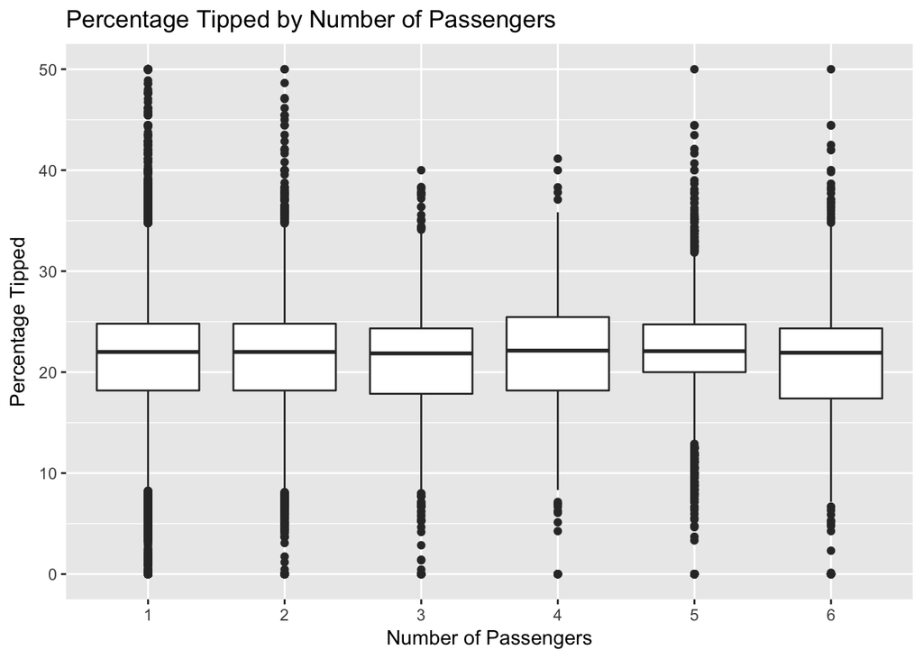

- Do people tip more if they get to where they are going more quickly?

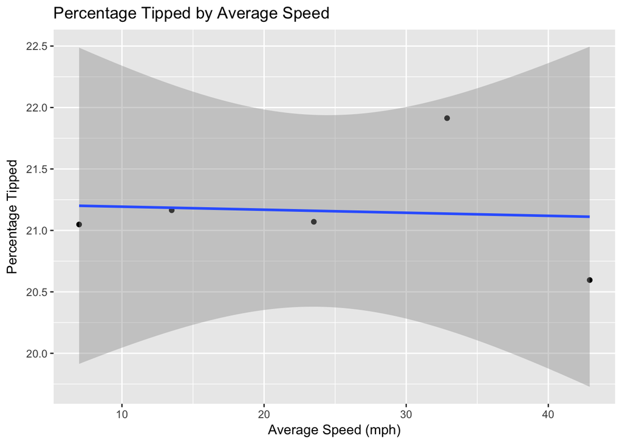

- All-subsets regression

```
##    (Intercept) pickup_hour pickup_latitude pickup_longitude dropoff_hour
## 1         TRUE       FALSE           FALSE            FALSE        FALSE
## 2         TRUE       FALSE           FALSE            FALSE        FALSE
## 3         TRUE       FALSE           FALSE            FALSE        FALSE
## 4         TRUE       FALSE           FALSE            FALSE        FALSE
## 5         TRUE        TRUE           FALSE            FALSE        FALSE
## 6         TRUE        TRUE           FALSE             TRUE        FALSE
## 7         TRUE        TRUE            TRUE             TRUE        FALSE
## 8         TRUE        TRUE            TRUE             TRUE        FALSE
## 9         TRUE        TRUE            TRUE             TRUE        FALSE
## 10        TRUE        TRUE            TRUE             TRUE         TRUE
## 11        TRUE        TRUE            TRUE             TRUE         TRUE
##    dropoff_latitude dropoff_longitude passenger_count tolls_amount extra
## 1             FALSE             FALSE           FALSE        FALSE  TRUE
## 2             FALSE             FALSE           FALSE         TRUE  TRUE
```

[output cut: 21 more lines]

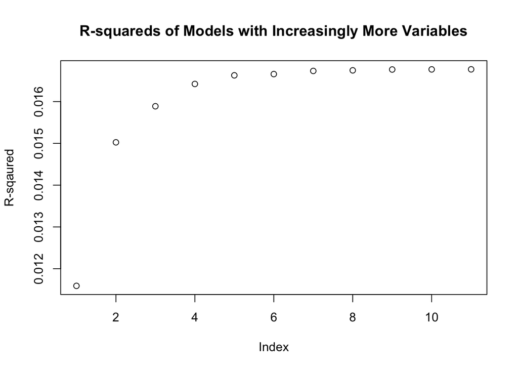

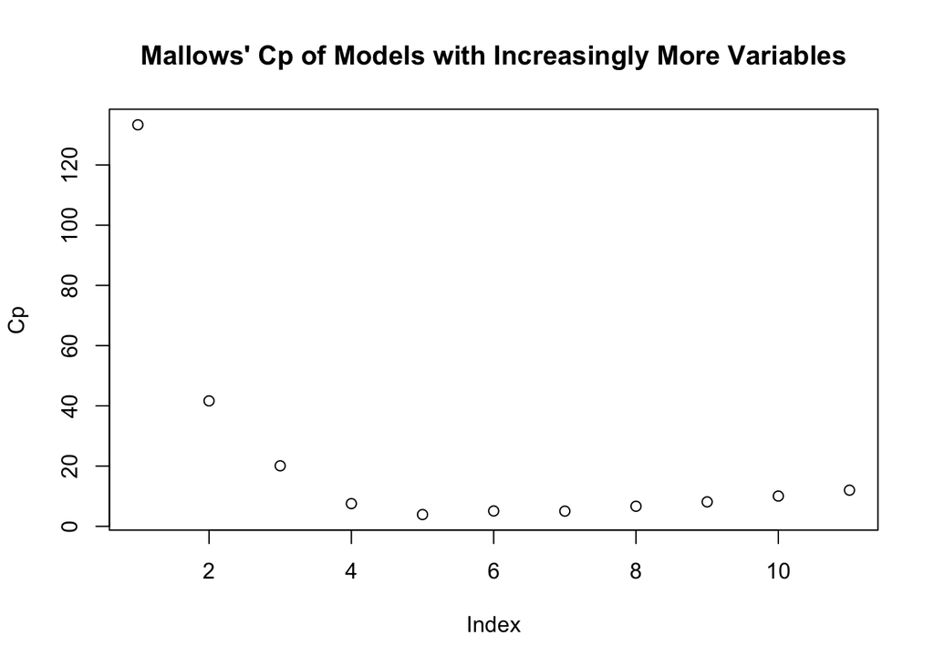

```
## [1] 5
```

```
## [1] "pickup_hour"       "dropoff_longitude" "tolls_amount"
## [4] "extra"             "avg_speed"
```